# Reclassifying NBA Player Postions Pt. 3 - Clustering Analysis Results

Mike Kaminski

2023-06-23

# Libraries

```r
library(tidymodels) # broom, dials, parsnip, tune, workflows, yardstick
library(tidyverse) #ggplot2, dplyr, tidyr, readr, purr, tibble, stringr, lubridate
library(gghighlight)
```

# Read in the Data

```r
NBACleanData <- read_csv("Data/model0611.csv",show_col_types = FALSE) %>% select(-1)
model_df <-  NBACleanData %>% select(-80) %>%
  mutate(Year = as.character(Year)) %>%
  mutate(across(where(is.numeric), ~as.numeric(scale(.))))
```

From Pt.2 of the project, I decided to use 7 clusters. Using PCA didn’t really provide improved results in the dataset, plus I need to be able to explain the results in a concise format. Therefore, I’ve opted to not use PCA to reduce dimensionality. I’ve also decided to use kmeans over hierarchical, as I think it will be a little bit easier to interpret.

# Modeling

From the last part, here is the model

```r
set.seed(1234)

nba_clust <- kmeans(model_df %>% select(-c(1:4)),
                    iter.max = 500 ,
                    nstart = 100 ,
                    centers = 7)
```

```r
head(augment(nba_clust, model_df)[, c(80,1:9)],5)
```

```
## # A tibble: 5 × 10
##   .cluster Year  Player   Pos   Tm      FG_pp  FGA_pp FG_pct_pp ThrP_pp ThrPA_pp
##   <fct>    <chr> <chr>    <chr> <chr>   <dbl>   <dbl>     <dbl>   <dbl>    <dbl>
## 1 3        2001  AC Green PF    MIA   -0.874  -0.899    -0.0991  -1.16    -1.20
## 2 2        2001  AJ Guyt… PG    CHI   -0.384  -0.0956   -0.681    0.533    0.393
## 3 5        2001  Aaron M… SG    PHI   -0.0274 -0.226     0.345   -0.274   -0.192
## 4 1        2001  Aaron W… PF    NJN   -0.429  -0.508     0.100   -1.16    -1.25
## 5 3        2001  Adam Ke… PF    GSW   -1.63   -1.55     -0.727   -1.08    -1.20
```

```r
nba_aug <- augment(nba_clust, model_df) %>%
  rename(Cluster = .cluster) %>%
  select(-c(1:4)) %>%
  select(Cluster, everything())

test <- nba_aug %>%
  pivot_longer(!Cluster, names_to = 'feature', values_to = 'value')
```

# Create a Dataframe for Plotting Results

```r
options(scipen = 99)
kmeans_centers <- data.frame(Cluster = c(paste0('Cluster ', 1:7)), nba_clust$centers) %>% #creates a column w/ the cluster name
  pivot_longer(!Cluster, names_to = 'feature', values_to = 'center') %>% #pivots longer for easier graphing
  mutate(feature = as.factor(feature)) %>% #makes the feature a factor
  mutate(Cluster = as.factor(Cluster))
head(kmeans_centers)
```

```
## # A tibble: 6 × 3
##   Cluster   feature     center
##   <fct>     <fct>        <dbl>
## 1 Cluster 1 FG_pp        1.12
## 2 Cluster 1 FGA_pp       0.716
## 3 Cluster 1 FG_pct_pp    0.796
## 4 Cluster 1 ThrP_pp     -0.801
## 5 Cluster 1 ThrPA_pp    -0.843
## 6 Cluster 1 ThrP_pct_pp -0.372
```

The plots below show the makeup of each cluster. Each stat category is listed on the x-axis and the cluster center is listed on the y-axis. The labels on each point represent the rank of that cluster within each stat category.

A rank of 1 in the per game pre 100 possessions, and advanced stat categories (suffixed with pp, pg, adv), indicate that players in that cluster performed particularly well in that category - with the exception being in the personal foul and turnover stat categories (PF and TOV), where a high value is less desirable

A rank of 1 in the shooting stat category is more informational rather than desirable or undesirable. It represents, among other stats, the distances where players are taking shots from. For example, it helps identify which players/clusters take 3-point shots vs shots close to the basket.

Looking at Cluster 1, we see that players in this cluster get a lot of rebounds (Reb_T, Reb_D, Reb_O) - they have a high cluster center and rank first within that category. We also see that they commit a lot of fouls and have a poor defensive rating. A high cluster center for fouls is undesirable and a low cluster center for defensive rating means that these players aren’t good at defense (more offensive minded).

I’ve included a new position name for each cluster, a summary of each position (aka cluster), and listed some of the players from the 2022 season that fall into each position.

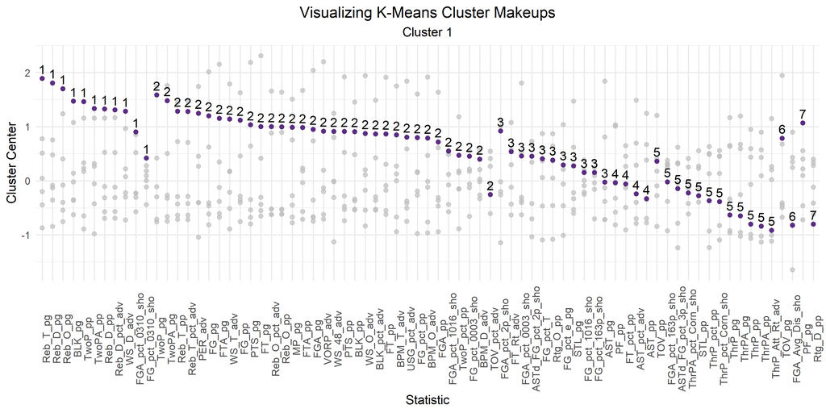

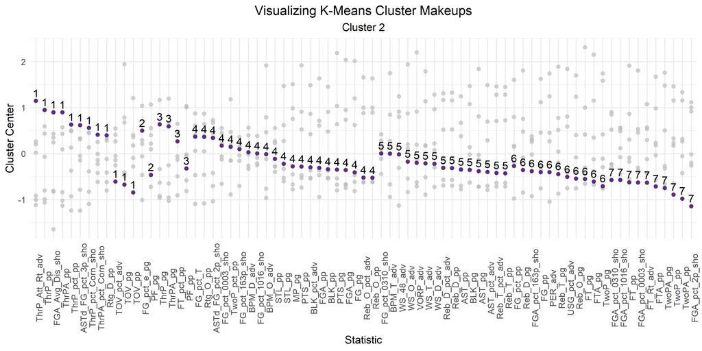

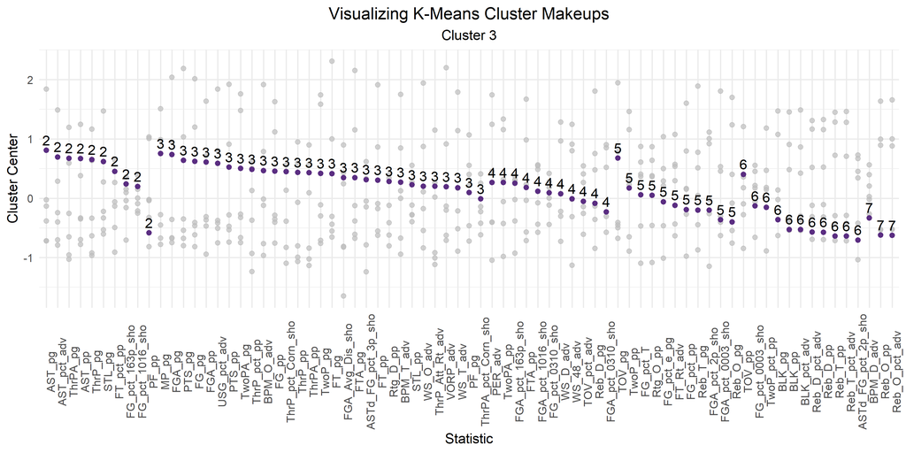

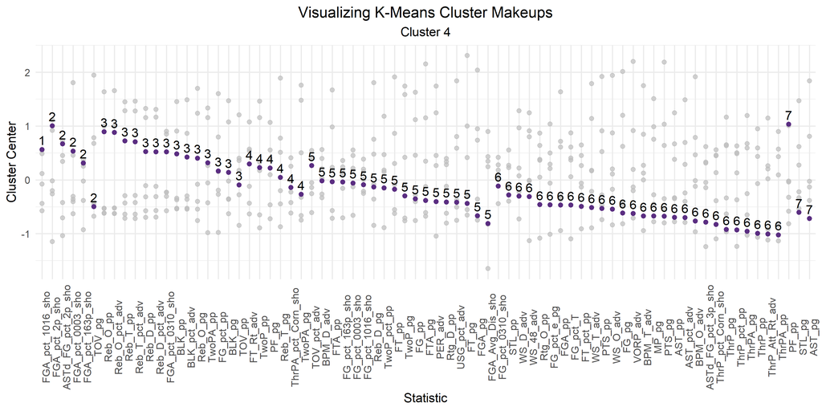

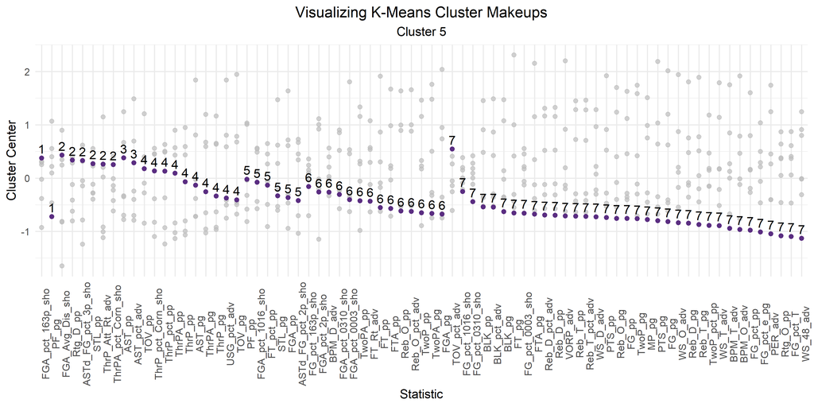

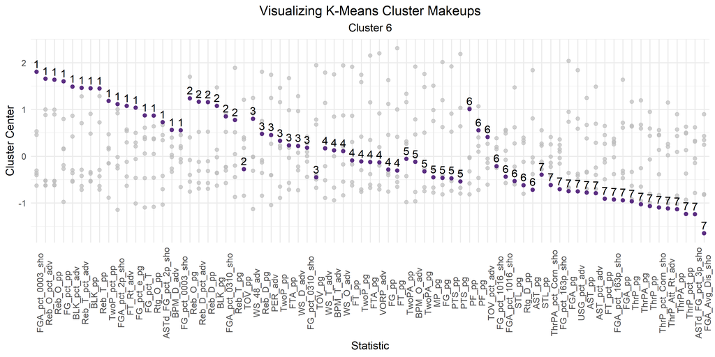

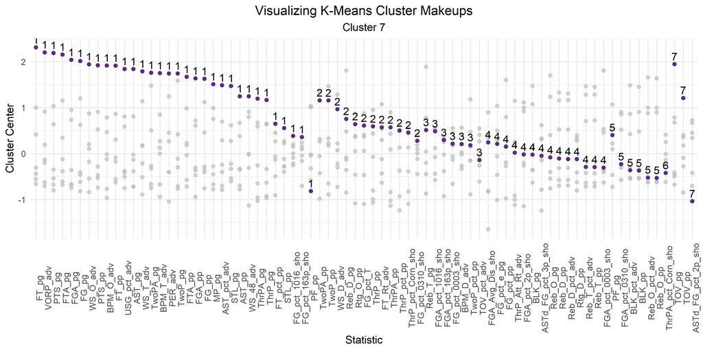

```r
#sets up the unique clusters for the for loop
unique_cluster <- unique(kmeans_centers$Cluster)

for (clust in unique_cluster) {

  # Filtered dataset for the specific value of clust
  filtered_data <- kmeans_centers %>%
    group_by(feature) %>%
    mutate(rank = ifelse(as.character(feature) %in% c('PF_pg', 'PF_pp', 'TOV_pg', 'TOV_pp', 'TOV_pct_adv'),
                                      rank(center),
                                      rank(desc(center)))
                         )%>% # adjust rank for high values in less desriable stat categories
    arrange(case_when(Cluster == clust ~ 1, TRUE ~ 2), Cluster, rank, desc(center)) %>%
    mutate(Cluster = as.character(Cluster)) %>%
    filter(Cluster == clust)

  plot <- kmeans_centers %>%
    group_by(feature) %>%
    mutate(rank = ifelse(as.character(feature) %in% c('PF_pg', 'PF_pp', 'TOV_pg', 'TOV_pp', 'TOV_pct_adv'),
                                      rank(center),
                                      rank(desc(center)))
                         )%>% # adjust rank for high values in less desriable stat categories
    arrange(case_when(Cluster == clust ~ 1, TRUE ~ 2), Cluster, rank, desc(center)) %>%
    ggplot(aes(x = factor(feature, levels = unique(feature)), y = center, color = clust)) +
    geom_point(color = "#5A2D81") +
    geom_text(data = filtered_data, aes(label = rank), color = "black", vjust = -0.5) +  # Add point labels for rank
    theme_minimal() +
    gghighlight(Cluster == clust, use_direct_label = FALSE) +
    theme(legend.position = "none",
          axis.text.x = element_text(angle = 90, size = 9, hjust = 0.5),
          axis.title = element_text(hjust = 0.5),
          plot.title = element_text(hjust = 0.5),
          plot.subtitle = element_text(hjust = 0.5)) +
    labs(x = "Statistic", y = "Cluster Center",
         title = "Visualizing K-Means Cluster Makeups",
         subtitle = clust)

  print(plot)
}
```

```r
final_df <- model_df %>%
  select(c(1:4)) %>%
  cbind(nba_aug) %>%
  mutate(Cluster = as.character(Cluster))

df_2022 <- final_df %>%
  filter(Year %in% '2022')

df_2022 %>%
  filter(Cluster == 1)
```

```
##    Year             Player Pos  Tm Cluster       FG_pp      FGA_pp FG_pct_pp
## 1  2022     Andre Drummond   C TOT       1  0.41821720 -0.42142727 1.8308441
## 2  2022    Bismack Biyombo   C PHO       1  0.28452358 -0.66037564 2.1831436
## 3  2022     Brandon Clarke  PF MEM       1  1.57689524  0.07819204 2.9643292
## 4  2022      Chris Boucher  PF TOR       1  0.15082996  0.05646946 0.2072034
## 5  2022       Clint Capela   C ATL       1  0.59647536 -0.50831759 2.4894909
## 6  2022        Cody Zeller   C POR       1 -0.25025089 -0.96449174 1.7848920
## 7  2022          DJ Wilson  PF TOR       1  1.17581438 -0.63865306 4.3275748
## 8  2022       Damian Jones   C SAC       1  0.32908812 -0.92104658 3.1787723
## 9  2022     Daniel Gafford   C WAS       1  0.99755622 -0.59520790 3.7148801
## 10 2022      DayRon Sharpe  PF BRK       1  1.39863708  0.36058556 1.9380657
## 11 2022     DeAndre Jordan   C TOT       1 -0.16112181 -1.22516268 2.9490119
## 12 2022     Dewayne Dedmon   C MIA       1  0.06170089 -0.70382079 1.7695747
## 13 2022     Draymond Green  PF GSW       1 -1.14154169 -1.61616910 1.1415627
## 14 2022       Drew Eubanks   C TOT       1  0.46278174 -0.53004017 2.2290957
```

[output cut: 720 more lines]

# Cluster 1:

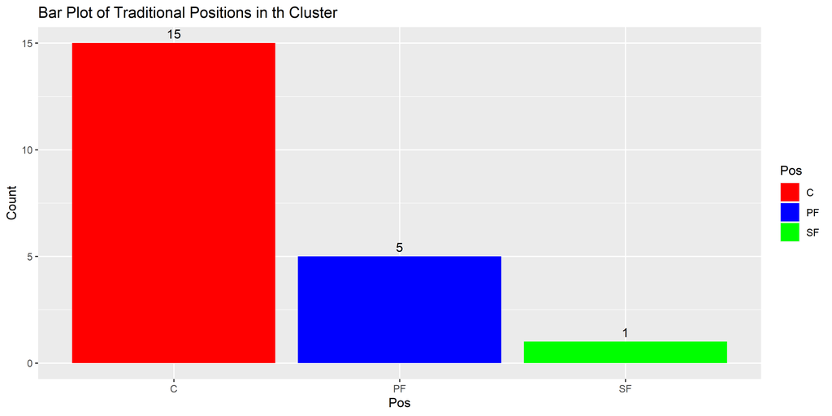

```r
df_2022 %>%
  filter(Cluster == 1) %>%
  ggplot(aes(x = Pos)) +
  geom_bar(aes(fill = Pos), stat = "count") +
   geom_text(stat = "count", aes(label = ..count..), vjust = -0.5, color = "black") +
  scale_fill_manual(values = c("red", "blue", "green")) +
  labs(x = "Pos", y = "Count", title = "Bar Plot of Traditional Positions in th Cluster")
```